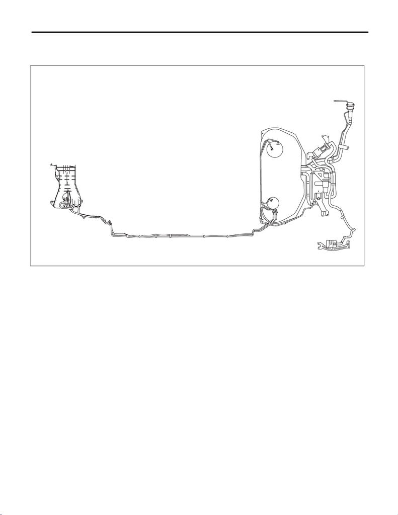

Fuel Delivery and Evaporation Lines

FUEL INJECTION (FUEL SYSTEMS)

40.Fuel Delivery and Evaporation Lines

A: REMOVAL

WARNING:

Place “NO OPEN FLAMES” signs near the working area.

CAUTION:

Be careful not to spill fuel.

DURE, Fuel.>

2) Open the fuel filler lid and remove the fuel filler cap.

NOTE:

This operation is required to release the inner pressure of the fuel tank.

3) Remove the floor mat. <Ref. to EI-105, REMOVAL, Floor Mat.>

FU-08306

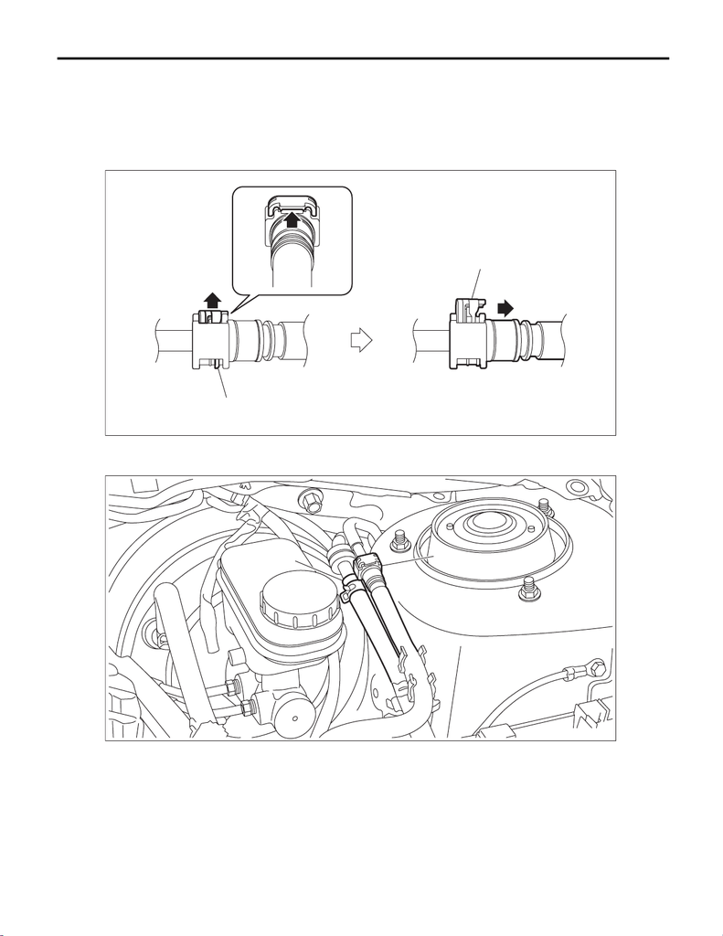

FU(w/o STI)-195

Fuel Delivery and Evaporation Lines

FUEL INJECTION (FUEL SYSTEMS)

4) In the engine compartment, disconnect the fuel delivery tube (A) and evaporation hose (B).

CAUTION:

• Be careful not to spill fuel.

• Catch the fuel from the tubes using a container or cloth.

NOTE:

Disconnect the quick connector as shown in the figure.

5) Remove the fuel tank. <Ref. to FU(w/o STI)-152, REMOVAL, Fuel Tank.>

(a) Slider

FU-07796

(a)

(a)

FU-07821

(A)

(B)

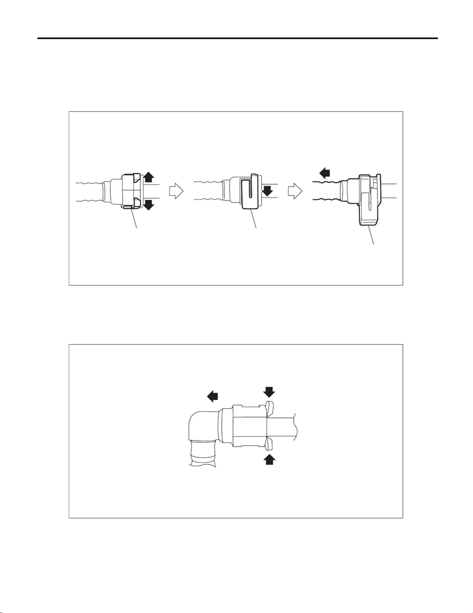

FU(w/o STI)-196

Fuel Delivery and Evaporation Lines

FUEL INJECTION (FUEL SYSTEMS)

6) Disconnect the quick connector, and remove the fuel delivery tube and jet pump tube from the fuel tank.

CAUTION:

• Be careful not to spill fuel.

• Catch the fuel from the tubes using a container or cloth.

NOTE:

Disconnect the quick connector as shown in the figure.

7) Disconnect the quick connector and remove the purge pipe.

NOTE:

Disconnect the quick connector as shown in the figure.

(a) Slider

EC-02771

(a)

(a)

(a)

FU-06563

1

1

2

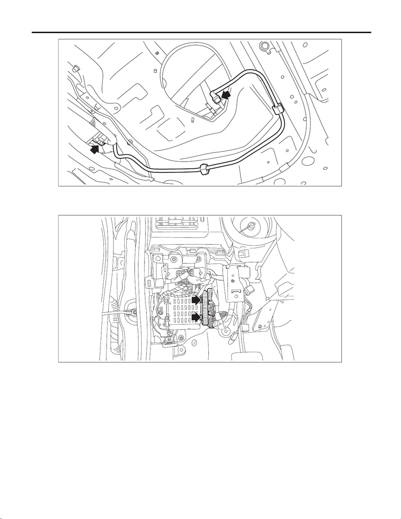

FU(w/o STI)-197

Fuel Delivery and Evaporation Lines

FUEL INJECTION (FUEL SYSTEMS)

8) Remove the body integrated unit.

(1) Remove the knee airbag module. <Ref. to AB-35, REMOVAL, Knee Airbag Module.>

(2) Release the lock and remove the fuse holder from the relay & fuse box.

(3) Disconnect the connectors from the relay & fuse box.

FU-08284

FU-08324

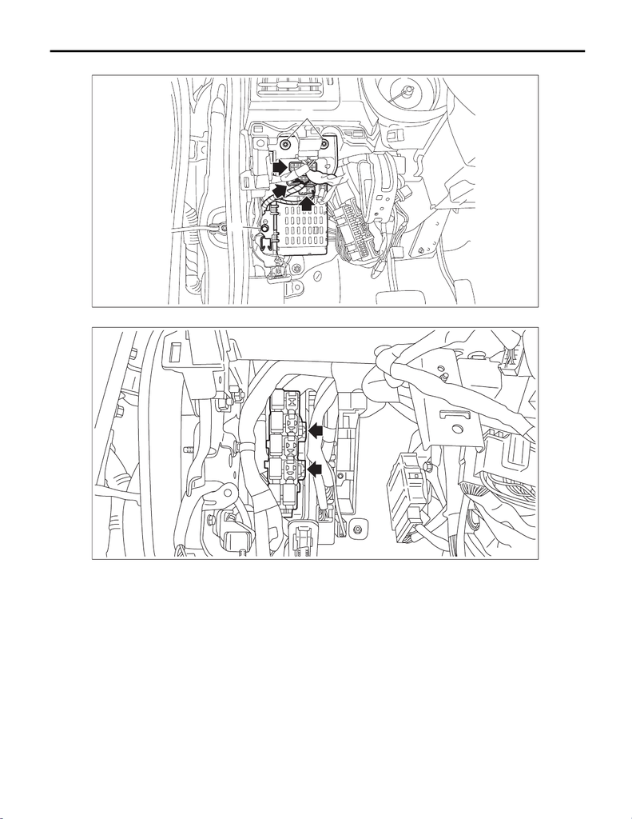

FU(w/o STI)-198

Fuel Delivery and Evaporation Lines

FUEL INJECTION (FUEL SYSTEMS)

(4) Remove the bolts (A) and nuts (B), and remove the relay & fuse box.

(5) Release the lock and remove the relay block.

(6) Disconnect the connector from body integrated unit.

FU-08325

(A)

(B)

FU-06724

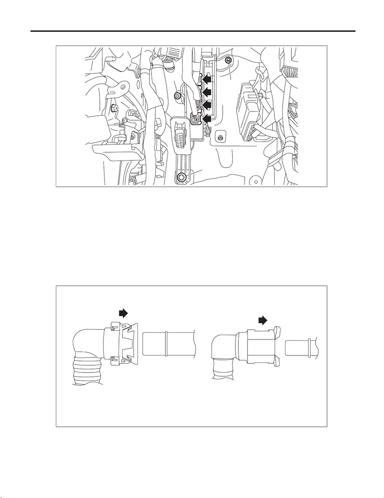

FU(w/o STI)-199

Fuel Delivery and Evaporation Lines

FUEL INJECTION (FUEL SYSTEMS)

(7) Remove the bolt (A) and nut (B), and remove the body integrated unit along with the bracket.

9) Remove the fuel pipe assembly from vehicle.

B: INSTALLATION

Install in the reverse order of removal while being careful of the following.

1. CONNECTING THE EVAPORATION LINE QUICK CONNECTOR

NOTE:

Connect the quick connector as shown in the figure.

CAUTION:

of the pipe.

• Make sure that the quick connector is securely connected.

FU-06725

(B)

(B)

(A)

FU-06594

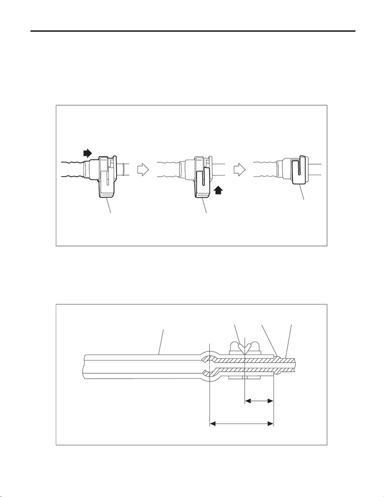

FU(w/o STI)-200

Fuel Delivery and Evaporation Lines

FUEL INJECTION (FUEL SYSTEMS)

2. CONNECTING THE FUEL LINE QUICK CONNECTOR

Connect the quick connector as shown in the figure.

CAUTION:

of the pipe.

• When connecting the quick connector, make sure to insert it all the way in before locking the slider.

• When it is difficult to lock the slider, check that the connector is fully inserted.

• After locking the slider, check again that the quick connector is securely connected.

3. EVAPORATION HOSE CONNECTION

Connect the evaporation hose by inserting it to the pipe until the hose reaches the spool or bump.

NOTE:

If there is no spool nor bump, connect the evaporation hose by inserting it at 28 mm (1.1 in) to the pipe.

(a) Slider

(1) Hose (3) Spool or bump (4) Pipe

(2) Clip

EC-02779

(a)

(a)

(a)

L

L/2

(1)

(2)

(3)

(4)

FU-06185

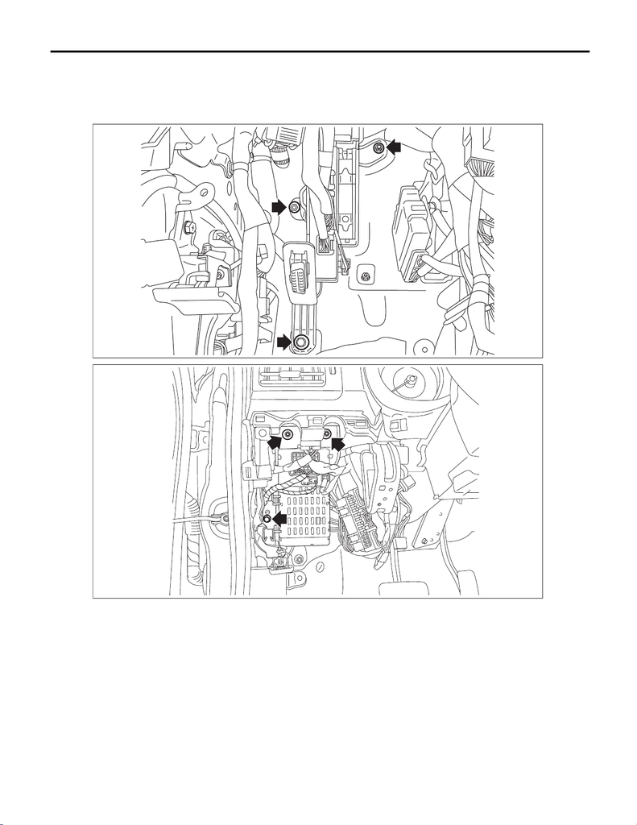

FU(w/o STI)-201

Fuel Delivery and Evaporation Lines

FUEL INJECTION (FUEL SYSTEMS)

4. BODY INTEGRATED UNIT INSTALLATION

Tighten the bolts and nuts in the figure to the torque specified below.

Tightening torque:

7.5 N·m (0.8 kgf-m, 5.5 ft-lb)

C: INSPECTION

1) Check that the fuel pipe has no deformation, cracks or other damages.

2) Check that the hose and tube have no cracks, damage or loose part.

FU-07954

FU-08326